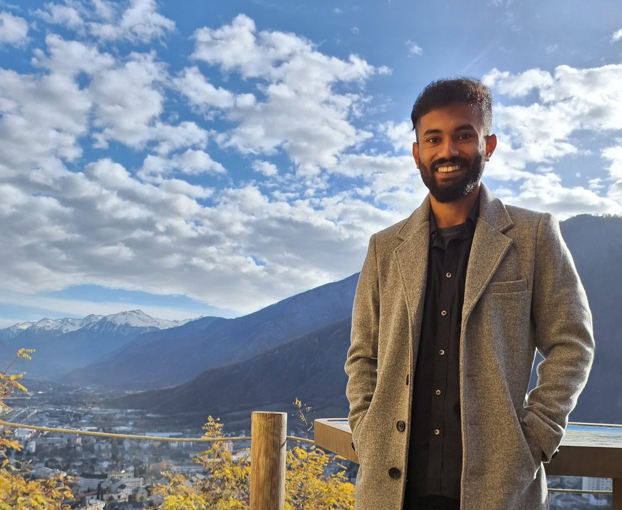

# Annesh Pal

## Hi there!

I am currently pursuing a doctoral degree in Biostatistics at the University of Bordeaux. My primary research interests include Bayesian Statistics, Mathematical modeling and Machine Learning, with particular emphasis on medical and biological data.

I completed 5-years’ Integrated BS-MS dual degree from Indian Institute of Science, Education and Research (IISER) Kolkata, India. My Master’s thesis involved analyzing the subjective nature of Bayesian paradigm, where the sensitivity of fish population estimates were studied based on choice of different weakly informative priors and loss functions.

My current research focuses on developing a novel semi-supervised clustering method for high-dimensional data sets. I am working on Dirichlet Process (DP) mixture models for kernel distributions of bulk transcriptomic data to allow discovery of new mixtures. The model will infer cellular proportions from RNA-seq data and thus help in predicting outcomes and evaluating surrogacy from clinical trial data sets.

## Education

**University of Bordeaux** | Bordeaux, France

Ph.D. in Biostatistics | December 2023 - Present

**Indian Institute of Science, Education and research** | Kolkata, India

Integrated B.S.-M.S. in Mathematics and statistics | August 2017 - July 2022